# 2 Module 2: Odds, Odds Ratios, and Interpretation

# 3 Odds Ratios and Interpretation

## 3.1 Learning outcomes

- Interpret coefficients as odds ratios.
- Explain why logistic effects are nonlinear on the probability scale.
- Generate scenario-based predictions for communication.

## 3.2 Coefficients and odds ratios

Logistic regression coefficients are changes in log-odds. Exponentiating a coefficient gives an odds ratio.

```r
fit <- glm(am ~ wt + hp, data = mtcars, family = binomial)
coef(fit)
```

```
(Intercept)          wt          hp
 18.8662987  -8.0834752   0.0362556
```

```r
exp(coef(fit))
```

```
 (Intercept)           wt           hp
1.561455e+08 3.085967e-04 1.036921e+00
```

**Key-point 1**

`exp(beta)` is the multiplicative change in odds for a one-unit increase in a predictor, holding others constant.

**Exercise 1**

Compute the odds ratio for `wt` and store it as `or_wt`.

## 3.3 Odds ratios are not probability differences

A fixed change in log-odds produces different changes in probability depending on the starting point.

```r
p <- c(0.1, 0.2, 0.4)
odds <- p / (1 - p)
cbind(p = p, odds = odds)
```

```
       p      odds
[1,] 0.1 0.1111111
[2,] 0.2 0.2500000
[3,] 0.4 0.6666667
```

**Note 1**

Odds ratios can look large even when the absolute probability change is modest. Always translate to predicted probabilities for interpretation.

- Continue

## 3.4 Scenario-based predictions

```r
new_cars <- data.frame(wt = c(2.2, 3.2, 3.8), hp = c(110, 110, 110))
predict(fit, newdata = new_cars, type = "response")
```

```
           1            2            3
0.9937615708 0.0468551348 0.0003846502
```

You can also visualize how the probability changes with weight while holding horsepower constant.

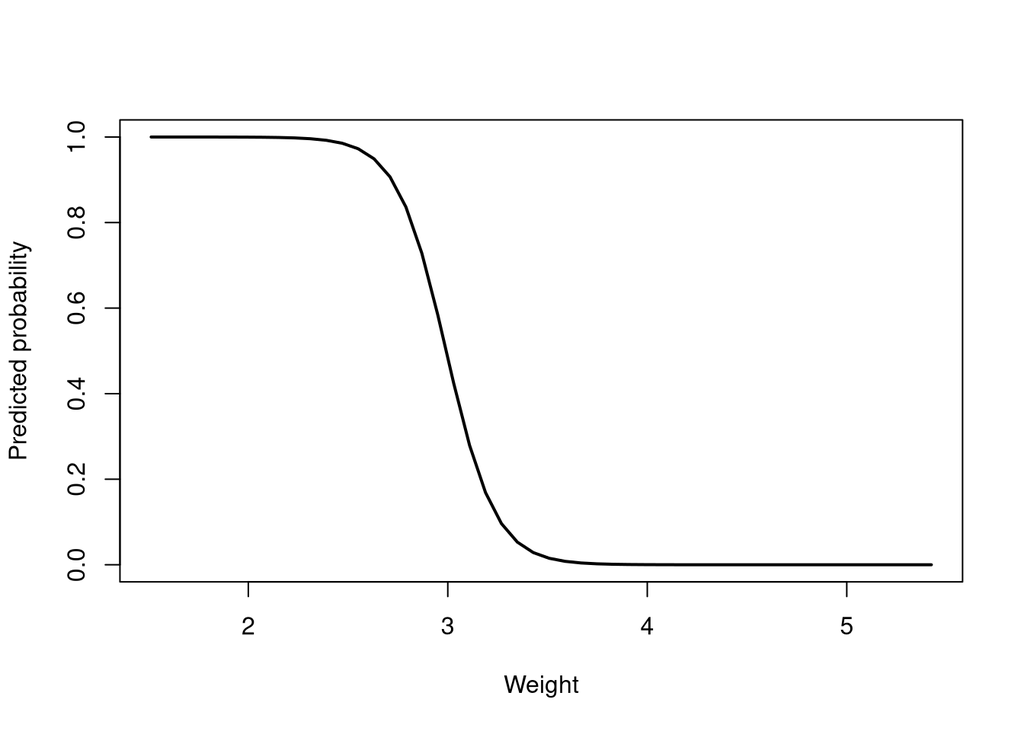

```r
grid <- data.frame(
  wt = seq(min(mtcars$wt), max(mtcars$wt), length.out = 50),
  hp = mean(mtcars$hp)
)
grid$prob <- predict(fit, newdata = grid, type = "response")
plot(grid$wt, grid$prob, type = "l", lwd = 2,
     xlab = "Weight", ylab = "Predicted probability")
```

**Exercise 2**

Compute the predicted probability for a car with weight 3.0 and horsepower 110. Store it as `p_case`.

## 3.5 Categorical predictors

```r
fit_cat <- glm(am ~ wt + factor(cyl), data = mtcars, family = binomial)
summary(fit_cat)
```

```
Call:
glm(formula = am ~ wt + factor(cyl), family = binomial, data = mtcars)

Coefficients:
             Estimate Std. Error z value Pr(>|z|)
(Intercept)    20.853      8.032   2.596  0.00942 **
wt             -7.859      3.055  -2.573  0.01009 *
factor(cyl)6    3.105      2.425   1.280  0.20042
factor(cyl)8    5.379      3.201   1.681  0.09281 .
---
Signif. codes:  0 '***' 0.001 '**' 0.01 '*' 0.05 '.' 0.1 ' ' 1

(Dispersion parameter for binomial family taken to be 1)

    Null deviance: 43.230  on 31  degrees of freedom
Residual deviance: 14.661  on 28  degrees of freedom
AIC: 22.661

Number of Fisher Scoring iterations: 7
```

When a predictor is a factor, coefficients compare each level to a reference level. Interpret them as odds ratios relative to that baseline.

## 3.6 Practice prompts

- Interpret `exp(coef(fit)["wt"])` in plain language.
- How does the predicted probability change between weights 2.2 and 3.8 in the curve above?
- Fit a model with `factor(gear)` instead of `factor(cyl)`. Which baseline does R pick?